# Reproduce multiPLIER Figure 3 - SLE WB Compendium

## GSEA

```r
## PCclusters containing the keyword, "neutrophil", in each GSEA result
a <- gsea(PCAmodel)
b <- sapply(a, function(x) {
  y <- x[order(x$NES, decreasing = TRUE),][1:3,]   # top 3 NES
  grep("neutrophil", y[["Description"]], ignore.case = TRUE)
  })
c <- sapply(b, length)
table(c)
```

```
#> c
#>    0    1    2
#> 4655   98   11
```

```r
## PCclusters with two keyword-containing pathways
which(c == 2)
```

```
#>    PCcluster7  PCcluster147  PCcluster172  PCcluster216  PCcluster560
#>             7           147           172           216           560
#> PCcluster1551 PCcluster1730 PCcluster1917 PCcluster2530 PCcluster2667
#>          1551          1730          1917          2530          2667
#> PCcluster2745
#>          2745
```

```r
sig_ind <- gsub("PCcluster", "", names(which(c == 2))) %>% as.numeric
```

## Metadta-associated

```r
calculateRsq <- function (x, y) cor(x, y) ^ 2
rsq <- function(data, lv, y.var = "Neutrophil_estimate") {
  res <- calculateRsq(data[, lv], data[, y.var]) %>% round(., 3)
  return(res)
}
```

### Neutrophil count

```r
sampleScore_sub <- sampleScore[,validated_ind] %>% as.data.frame
sampleScore_sub$Source.Name <- rownames(sampleScore_sub)

dat_n.count <- dplyr::left_join(neutrophilCount, sampleScore_sub,
                                by = "Source.Name")
head(dat_n.count, 3)
```

```
#>   Source.Name Neutrophil.Count PCcluster1551 PCcluster23 PCcluster2671
#> 1  GSM1595222            12.23     3.0043652  -2.9752190    -2.5626217
#> 2  GSM1595221             6.20     1.2174456  -1.2722006    -0.2296332
#> 3  GSM1595220             3.50    -0.4207508   0.3739369     0.7214394
#>   PCcluster776 PCcluster1830
#> 1   -3.7585385     0.4322945
#> 2   -1.3472067     2.2002468
#> 3    0.5571763    -0.0339016
```

Top PCclusters with the high correlation (r-squared) with the metadata, neutrophil count.

```r
rsq_all <- sapply(3:ncol(dat_n.count),
                  function(x) {rsq(dat_n.count, x, y.var = "Neutrophil.Count")})
names(rsq_all) <- colnames(dat_n.count)[3:ncol(dat_n.count)]
rsq_all <- sort(rsq_all, decreasing = TRUE)
head(names(rsq_all))
```

```
#> [1] "PCcluster1551" "PCcluster776"  "PCcluster23"   "PCcluster2671"
#> [5] "PCcluster1830"
```

### Neutrophil estimate

```r
sampleScore.df <- sampleScore %>% as.data.frame(.) %>%
  tibble::rownames_to_column(.)
colnames(sampleScore.df)[1] <- "Sample"

## Join all the scores with neutrophil estimates
dat_n.estimate <- dplyr::inner_join(neutrophil.df, sampleScore.df, by = "Sample")
dim(dat_n.estimate)
```

```
#> [1]  853 4766
```

```r
dat_n.estimate[1:4, 1:4]
```

```
#>       Sample Neutrophil_estimate PCcluster1  PCcluster2
#> 1 GSM1594269           0.5210433 -0.8040057  0.70872695
#> 2 GSM1594270           0.4624522  0.9403239 -1.13442804
#> 3 GSM1594271           0.6052038 -1.1120027  2.28676223
#> 4 GSM1594273           0.3782767  0.3042759 -0.01665221
```

Top PCclusters with the high correlation (r-squared) with the neutrophil estimate.

```r
rsq_all <- sapply(3:ncol(dat_n.estimate), function(x) {rsq(dat_n.estimate,x)})
names(rsq_all) <- colnames(dat_n.estimate)[3:ncol(dat_n.estimate)]
rsq_all <- sort(rsq_all, decreasing = TRUE)
head(names(rsq_all))
```

```
#> [1] "PCcluster1551" "PCcluster7"    "PCcluster1073" "PCcluster2632"
#> [5] "PCcluster23"   "PCcluster2671"
```

# Interpret score

## Score vs. Neutrophil counts

### PCclusters selected through validation score

Scores from the validated indexes are compared to the nuetrophil counts.

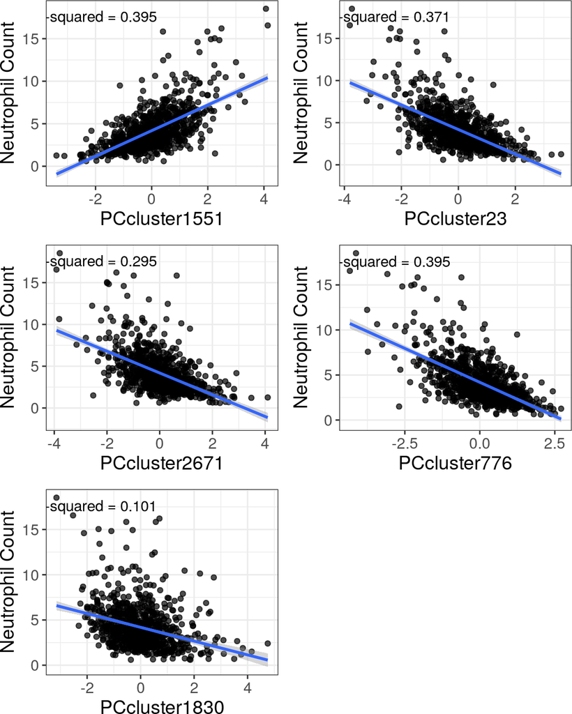

```r
plots <- list()
for (i in seq_along(validated_ind)) {
  plot <- LVScatter(dat_n.count, paste0("PCcluster", validated_ind[i]),
                    y.var = "Neutrophil.Count",
                    ylab = "Neutrophil Count")
  plots[[i]] <- plot
}

gridExtra::grid.arrange(grobs = plots, cols = 2)
```

## Score vs. Neutrophil estimates

### PCclusters selected through validation score

Scores from the validated indexes are compared to the nuetrophil estimates.

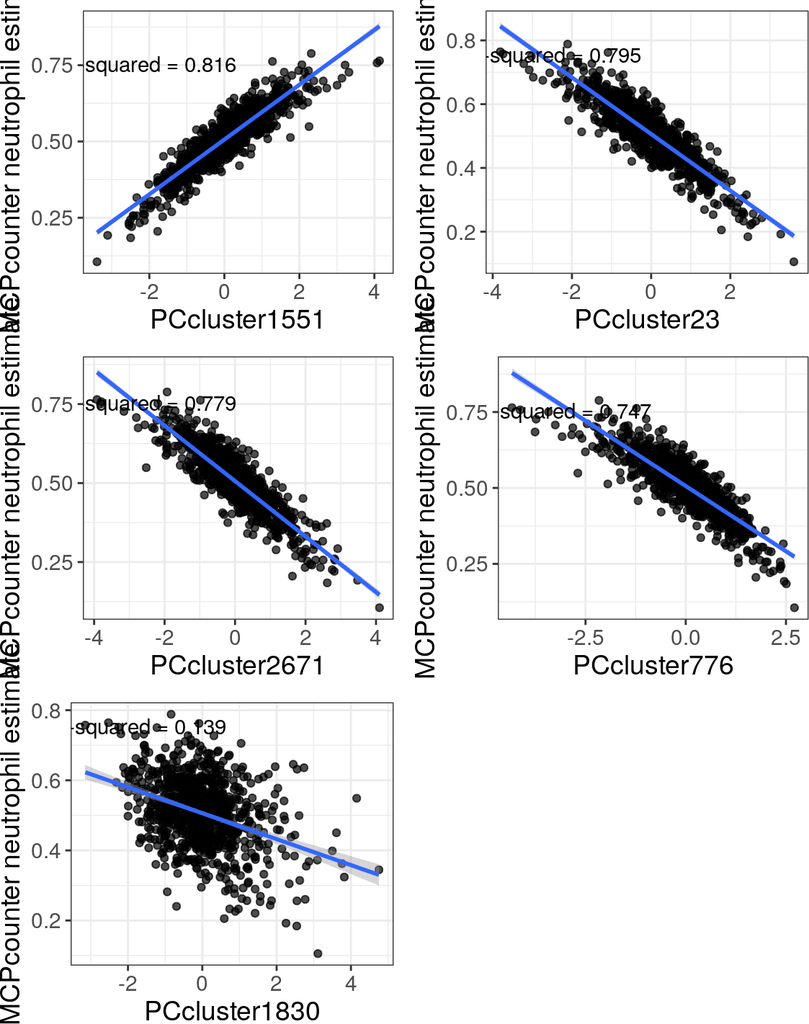

```r
plots <- list()
for (i in seq_along(validated_ind)) {
  plot <- LVScatter(dat_n.estimate, paste0("PCcluster", validated_ind[i]),
                    y.var = "Neutrophil_estimate",
                    ylab = "MCPcounter neutrophil estimate")
  plots[[i]] <- plot
}

gridExtra::grid.arrange(grobs = plots, cols = 2)
```

### PCclusters selected through GSEA

We found PCclusters that contain the keyword, “neutrophil”, most in their GSEA result and their indexes are saved in `sig_ind`.

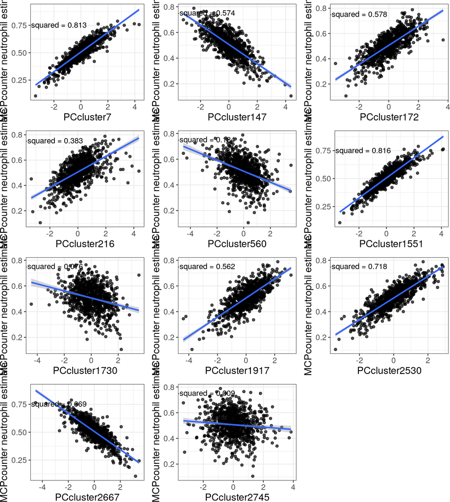

```r
plots <- list()
for (i in seq_along(sig_ind)) {
  plot <- LVScatter(dat_n.estimate, paste0("PCcluster", sig_ind[i]),
                    y.var = "Neutrophil_estimate",
                    ylab = "MCPcounter neutrophil estimate")
  plots[[i]] <- plot
}

gridExtra::grid.arrange(grobs = plots, cols = 3)
```

# Summary of Neutrophil-associated PCcluster1551

We recovered PCcluster1551 as a neutrophil-associated signature through validation, GSEA, metadata-association.

### Validation

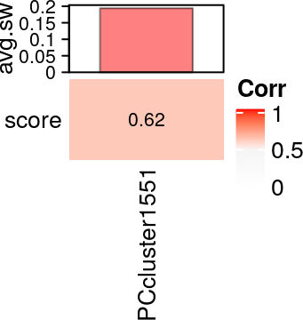

```r
heatmapTable(val_all, 1551)
```

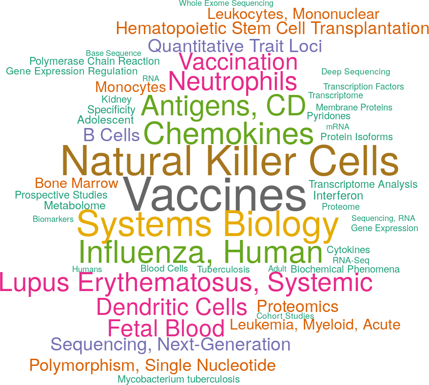

```r
drawWordcloud(PCAmodel, 1551)
```

### GSEA

```
#>  [1] "IRIS_Neutrophil-Resting"
#>  [2] "IRIS_Monocyte-Day0"
#>  [3] "SVM Neutrophils"
#>  [4] "DMAP_MONO2"
#>  [5] "SVM Monocytes"
#>  [6] "DMAP_GRAN2"
#>  [7] "DMAP_MONO1"
#>  [8] "IRIS_Monocyte-Day1"
#>  [9] "IRIS_Monocyte-Day7"
#> [10] "REACTOME_METABOLISM_OF_PROTEINS"
#> [11] "REACTOME_INFLUENZA_LIFE_CYCLE"
#> [12] "MIPS_55S_RIBOSOME_MITOCHONDRIAL"
#> [13] "REACTOME_TRANSLATION"
#> [14] "REACTOME_3_UTR_MEDIATED_TRANSLATIONAL_REGULATION"
#> [15] "DMAP_TCELLA2"
#> [16] "REACTOME_INFLUENZA_VIRAL_RNA_TRANSCRIPTION_AND_REPLICATION"
#> [17] "MIPS_NOP56P_ASSOCIATED_PRE_RRNA_COMPLEX"
#> [18] "REACTOME_NONSENSE_MEDIATED_DECAY_ENHANCED_BY_THE_EXON_JUNCTION_COMPLEX"
#> [19] "KEGG_RIBOSOME"
#> [20] "MIPS_RIBOSOME_CYTOPLASMIC"
#> [21] "REACTOME_PEPTIDE_CHAIN_ELONGATION"
#> [22] "REACTOME_SRP_DEPENDENT_COTRANSLATIONAL_PROTEIN_TARGETING_TO_MEMBRANE"
```

NES-ranked, keyword-containing pathways were placed 1/3 out of 22

```
#>                                     Description      NES      qvalues
#> IRIS_Neutrophil-Resting IRIS_Neutrophil-Resting 4.253400 1.827751e-09
#> SVM Neutrophils                 SVM Neutrophils 3.311116 1.827751e-09
```

### Annotate PC1

```r
annotatePC(1:3, val_all = val_all, PCAmodel = PCAmodel)
```

```
#>         PC1-PCcluster1551             PC2-noAnnot             PC3-noAnnot
#> 1 IRIS_Neutrophil-Resting No significant pathways No significant pathways
#> 2      IRIS_Monocyte-Day0 No significant pathways No significant pathways
#> 3         SVM Neutrophils No significant pathways No significant pathways
#> 4              DMAP_MONO2 No significant pathways No significant pathways
#> 5           SVM Monocytes No significant pathways No significant pathways
```

```r
annotatePC(c(1,8), val_all = val_all, PCAmodel = PCAmodel, simplify = FALSE)
```

```
#> $`PC1-PCcluster1551`
#>               Description      NES      qvalues
#> 1 IRIS_Neutrophil-Resting 4.253400 1.827751e-09
#> 2      IRIS_Monocyte-Day0 3.452230 1.827751e-09
#> 3         SVM Neutrophils 3.311116 1.827751e-09
#> 4              DMAP_MONO2 3.153644 1.827751e-09
#> 5           SVM Monocytes 3.107646 1.827751e-09
#>
#> $`PC8-noAnnot`
#>               Description NES qvalues
#> 1 No significant pathways  NA      NA
#> 2 No significant pathways  NA      NA
#> 3 No significant pathways  NA      NA
#> 4 No significant pathways  NA      NA
#> 5 No significant pathways  NA      NA
```